# A gentle introduction to the anthromes R package

This vignette presents an example workflow for using the `anthromes` R package for analyzing long-term human populations and land use.

First load the `anthromes` package.

```r
# analysis packages
library(anthromes)
library(stars)
library(dplyr)
```

```r
library(ggplot2)
# visualization packages
library(gganimate)
library(patchwork)
```

Although the package is able to work with global data, we’ll focus just on a subset of the eastern Mediterranean for simplicity.

```r
bbox <- st_bbox(c(xmin = 29, xmax = 39, ymin = 30, ymax = 40), crs = 4326)
```

# Download HYDE 3.2 data

Read in the anthromes data as a stars object. stars in an R package for working with space-time cubes like the HYDE 3.2 data, which are spatial rasters representing multiple time steps.

```r
hyde_med
```

```
#> stars object with 3 dimensions and 6 attributes
#> attribute(s):
#>             Min.      1st Qu.      Median         Mean    3rd Qu.         Max.
#> crops          0  0.000179287   1.3989784    8.5791286  10.348840      74.3285
#> grazing        0  0.068011791   0.9421589    4.0070415   3.382091      74.0772
#> rice           0  0.000000000   0.0000000    0.1056585   0.000000      73.8234
#> pop            0 65.238454819 222.5272064 2060.4865140 620.780472 1802804.1250
#> irrigation     0  0.000000000   0.0000000    1.3722187   0.000000      74.2032
#> urban          0  0.000000000   0.0000000    0.1139881   0.000000      74.3285
#>              NA's
#> crops       27132
#> grazing     27132
#> rice        27132
#> pop         27132
#> irrigation  27132
#> urban       27132
#> dimension(s):
#>      from   to  offset      delta refsys point            values x/y
#> x    2509 2629    -180  0.0833333 WGS 84 FALSE              NULL [x]
#> y     600  720 89.9999 -0.0833333 WGS 84 FALSE              NULL [y]
#> time    1    6      NA         NA     NA    NA 3000BC,...,2000AD
```

A stars object prints two pieces of information, the attribute data (which is essentially a tibble that can be manipulated via typical tidyverse functions) and dimension information (which records the spatial and temporal dimensions of the object).

```r
hyde_med
```

```
#> stars object with 3 dimensions and 6 attributes
#> attribute(s):
#>             Min.      1st Qu.      Median         Mean    3rd Qu.         Max.
#> crops          0  0.000179287   1.3989784    8.5791286  10.348840      74.3285
#> grazing        0  0.068011791   0.9421589    4.0070415   3.382091      74.0772
#> rice           0  0.000000000   0.0000000    0.1056585   0.000000      73.8234
#> pop            0 65.238454819 222.5272064 2060.4865140 620.780472 1802804.1250
#> irrigation     0  0.000000000   0.0000000    1.3722187   0.000000      74.2032
#> urban          0  0.000000000   0.0000000    0.1139881   0.000000      74.3285
#>              NA's
#> crops       27132
#> grazing     27132
#> rice        27132
#> pop         27132
#> irrigation  27132
#> urban       27132
#> dimension(s):
#>      from   to  offset      delta refsys point            values x/y
#> x    2509 2629    -180  0.0833333 WGS 84 FALSE              NULL [x]
#> y     600  720 89.9999 -0.0833333 WGS 84 FALSE              NULL [y]
#> time    1    6      NA         NA     NA    NA 3000BC,...,2000AD
```

Stars objects are useful for many reasons. One is that they can take units.

```r
hyde_med %>% dplyr::mutate(crops = units::set_units(crops, km2))
```

```
#> stars object with 3 dimensions and 6 attributes
#> attribute(s):
#>             Min.      1st Qu.      Median         Mean    3rd Qu.         Max.
#> crops [km2]    0  0.000179287   1.3989784    8.5791286  10.348840      74.3285
#> grazing        0  0.068011791   0.9421589    4.0070415   3.382091      74.0772
#> rice           0  0.000000000   0.0000000    0.1056585   0.000000      73.8234
#> pop            0 65.238454819 222.5272064 2060.4865140 620.780472 1802804.1250
#> irrigation     0  0.000000000   0.0000000    1.3722187   0.000000      74.2032
#> urban          0  0.000000000   0.0000000    0.1139881   0.000000      74.3285
#>              NA's
#> crops [km2] 27132
#> grazing     27132
#> rice        27132
#> pop         27132
#> irrigation  27132
#> urban       27132
#> dimension(s):
#>      from   to  offset      delta refsys point            values x/y
#> x    2509 2629    -180  0.0833333 WGS 84 FALSE              NULL [x]
#> y     600  720 89.9999 -0.0833333 WGS 84 FALSE              NULL [y]
#> time    1    6      NA         NA     NA    NA 3000BC,...,2000AD
```

Also load in the HYDE 3.2 supporting grids: land area, potential vegetation, and potential villages.

```r
inputs_med
```

```
#> stars object with 2 dimensions and 5 attributes
#> attribute(s):
#>    land_area                                            pot_veg
#>  Min.   : 1.032   Open Shrubland                            :2700
#>  1st Qu.:67.003   Grassland and Steppe                      :2022
#>  Median :68.686   Desert and Barren                         :1886
#>  Mean   :68.250   Savanna                                   :1245
#>  3rd Qu.:72.383   Temperate Broadleaf and Evergreen Woodland:1001
#>  Max.   :74.328   (Other)                                   :1265
#>  NA's   :4522     NA's                                      :4522
#>       regions           iso         pot_vill
#>  Near East:10119   Min.   :196    Min.   :1
#>  Africa   :    0   1st Qu.:760    1st Qu.:1
#>  Asia     :    0   Median :792    Median :1
#>  Eurasia  :    0   Mean   :713    Mean   :1
#>  Europe   :    0   3rd Qu.:792    3rd Qu.:1
#>  (Other)  :    0   Max.   :818    Max.   :1
#>  NA's     : 4522   NA's   :4522   NA's   :4522
#> dimension(s):
#>   from   to  offset      delta refsys point values x/y
#> x 2509 2629    -180  0.0833333 WGS 84 FALSE   NULL [x]
#> y  600  720 89.9999 -0.0833333 WGS 84 FALSE   NULL [y]
```

You can easily plot these objects in ggplot using geom_stars().

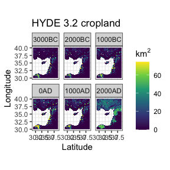

```r
ggplot() +
  geom_stars(data = hyde_med) +
  facet_wrap(~time) +
  coord_quickmap() +
  scale_fill_viridis_c(na.value = NA, name = expression(km^2)) +
  theme_bw() +
  labs(title = 'HYDE 3.2 cropland', x = 'Latitude', y = 'Longitude')
```

You can easily animate these data using gganimate.

```r
ggplot() +
  geom_stars(data = filter(hyde_med)) +
  coord_quickmap() +
  scale_fill_viridis_c(na.value = NA, name = expression(km^2)) +
  theme_bw() +
  # use transition_states() from gganimate instead of facet_wrap
  gganimate::transition_states(time) +
  labs(title = 'HYDE 3.2 land use', subtitle = 'Cropland at {closest_state}', x = 'Latitude', y = 'Longitude')
```

[output not shown]

By default, geom_stars will only plot the first attribute. If you’d like to plot multiple attributes at a time, the easiest way is to convert the attributes to an extra dimension.

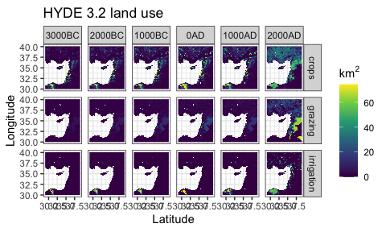

```r
ggplot() +
  geom_stars(data = merge(hyde_med[c(1:2,5),,,])) +
  facet_grid(attributes~time) +
  coord_quickmap() +
  scale_fill_viridis_c(na.value = NA, name = expression(km^2)) +
  theme_bw() +
  labs(title = 'HYDE 3.2 land use', x = 'Latitude', y = 'Longitude')
```

# Apply anthromes classification

```r
anthromes <- anthrome_classify(hyde_med, inputs_med)
```

[figure not shown]

[figure not shown]

```r
ggplot() +
  geom_stars(data = anthromes) +
  facet_wrap(~time) +
  coord_quickmap() +
  scale_fill_manual(values = anthrome_colors(), drop = TRUE) +
  theme_bw() +
  labs(title = 'Anthromes-12k', x = 'Latitude', y = 'Longitude')
```

```r
knitr::knit_exit()
```